```python
# Import required packages
import numpy as np
import matplotlib.pyplot as plt
from matplotlib.animation import FuncAnimation
from IPython.display import HTML
import pandas as pd
from mpl_toolkits.mplot3d import Axes3D

# Set random seed for reproducibility
np.random.seed(42)

print("✅ Packages loaded successfully")
print("🎯 Ready to explore MD and docking theory!")
```

```
✅ Packages loaded successfully
🎯 Ready to explore MD and docking theory!
```

# Part 1: Molecular Dynamics Theory

## 1.1 Force Fields and Potential Energy

MD simulations use **force fields** to calculate forces between atoms. The most common is the **Lennard-Jones potential**:

$$V_{LJ}(r) = 4\epsilon \left[\left(\frac{\sigma}{r}\right)^{12} - \left(\frac{\sigma}{r}\right)^6\right]$$

Where:

- $r$ = distance between atoms
- $\epsilon$ = depth of potential well (interaction strength)
- $\sigma$ = distance at which potential is zero

**Physical meaning**:

- $r^{-12}$ term: Pauli repulsion (atoms can't overlap)
- $r^{-6}$ term: Van der Waals attraction

The force is derived as: $F(r) = -\frac{dV}{dr}$

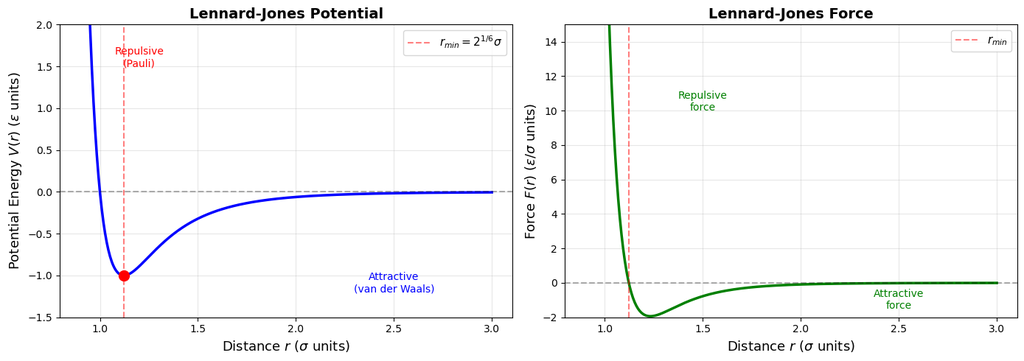

```
📊 Key observations:
   • Minimum energy at r = 1.122σ (equilibrium distance)
   • Minimum energy = -1.000ε
   • Force is zero at equilibrium (stable configuration)
   • Short range: Strong repulsion (atoms can't overlap)
   • Long range: Weak attraction (van der Waals forces)
```

```python
def lennard_jones_potential(r, epsilon=1.0, sigma=1.0):
    """Lennard-Jones potential energy"""
    return 4 * epsilon * ((sigma / r)**12 - (sigma / r)**6)

def lennard_jones_force(r, epsilon=1.0, sigma=1.0):
    """Lennard-Jones force (negative gradient of potential)"""
    return 24 * epsilon * (2 * (sigma / r)**13 - (sigma / r)**7) / r

# Plot potential and force
r = np.linspace(0.9, 3.0, 500)
V = lennard_jones_potential(r)
F = lennard_jones_force(r)

fig, (ax1, ax2) = plt.subplots(1, 2, figsize=(14, 5))

# Potential energy
ax1.plot(r, V, 'b-', linewidth=2.5)
ax1.axhline(y=0, color='k', linestyle='--', alpha=0.3)
ax1.axvline(x=2**(1/6), color='r', linestyle='--', alpha=0.5, label=r'$r_{min} = 2^{1/6}\sigma$')
ax1.scatter([2**(1/6)], [lennard_jones_potential(2**(1/6))], color='red', s=100, zorder=5)
ax1.set_xlabel(r'Distance $r$ ($\sigma$ units)', fontsize=13)
ax1.set_ylabel(r'Potential Energy $V(r)$ ($\epsilon$ units)', fontsize=13)
ax1.set_title('Lennard-Jones Potential', fontsize=14, fontweight='bold')
ax1.set_ylim(-1.5, 2)
ax1.grid(True, alpha=0.3)
ax1.legend(fontsize=11)
ax1.text(2.5, -1.2, 'Attractive\n(van der Waals)', ha='center', fontsize=10, color='blue')
ax1.text(1.2, 1.5, 'Repulsive\n(Pauli)', ha='center', fontsize=10, color='red')

# Force
ax2.plot(r, F, 'g-', linewidth=2.5)
ax2.axhline(y=0, color='k', linestyle='--', alpha=0.3)
ax2.axvline(x=2**(1/6), color='r', linestyle='--', alpha=0.5, label=r'$r_{min}$')
ax2.set_xlabel(r'Distance $r$ ($\sigma$ units)', fontsize=13)
ax2.set_ylabel(r'Force $F(r)$ ($\epsilon/\sigma$ units)', fontsize=13)
ax2.set_title('Lennard-Jones Force', fontsize=14, fontweight='bold')
ax2.set_ylim(-2, 15)
ax2.grid(True, alpha=0.3)
ax2.legend(fontsize=11)
ax2.text(1.5, 10, 'Repulsive\nforce', ha='center', fontsize=10, color='green')
ax2.text(2.5, -1.5, 'Attractive\nforce', ha='center', fontsize=10, color='green')

plt.tight_layout()
plt.show()

print(f"\n📊 Key observations:")
print(f"   • Minimum energy at r = {2**(1/6):.3f}σ (equilibrium distance)")
print(f"   • Minimum energy = {lennard_jones_potential(2**(1/6)):.3f}ε")
print(f"   • Force is zero at equilibrium (stable configuration)")
print(f"   • Short range: Strong repulsion (atoms can't overlap)")
print(f"   • Long range: Weak attraction (van der Waals forces)")
```

## 1.2 Newton's Equations of Motion

MD simulations solve Newton's 2nd law for all atoms:

$$F_i = m_i a_i = m_i \frac{d^2 r_i}{dt^2}$$

Where:

- $F_i$ = force on atom $i$ (from potential energy)
- $m_i$ = mass of atom $i$
- $a_i$ = acceleration of atom $i$

**Integration algorithm** (Velocity Verlet):

1. Update positions: $r(t + \Delta t) = r(t) + v(t)\Delta t + \frac{1}{2}a(t)\Delta t^2$
2. Calculate new forces: $F(t + \Delta t)$ from new positions
3. Update velocities: $v(t + \Delta t) = v(t) + \frac{1}{2}[a(t) + a(t + \Delta t)]\Delta t$

**Why Verlet?** It conserves energy better than simple Euler integration.

```python
class SimpleMD:
    """Simple 2D molecular dynamics simulator"""

    def __init__(self, n_particles=20, box_size=10.0, epsilon=1.0, sigma=1.0, dt=0.002):
        self.n_particles = n_particles
        self.box_size = box_size
        self.epsilon = epsilon
        self.sigma = sigma
        self.dt = dt

        # Initialize positions on a grid with MUCH larger spacing
        grid_size = int(np.ceil(np.sqrt(n_particles)))
        spacing = box_size / (grid_size + 1)

        # Ensure minimum distance is at least 2*sigma (well beyond LJ minimum)
        min_distance = 2.0 * sigma
        if spacing < min_distance:
            print(f"⚠️  Warning: Box too small for {n_particles} particles. Reducing to fit safely.")
            n_particles = int((box_size / min_distance)**2 * 0.8)
            self.n_particles = n_particles
            grid_size = int(np.ceil(np.sqrt(n_particles)))
            spacing = box_size / (grid_size + 1)

        positions = []
        for i in range(n_particles):
            row = i // grid_size
            col = i % grid_size
            # Place on grid with NO jitter initially
            x = (col + 1) * spacing
            y = (row + 1) * spacing
            positions.append([x, y])
        self.positions = np.array(positions)

        # Initialize velocities (Maxwell-Boltzmann at T=1.0)
        # Small initial velocities
        self.velocities = np.random.randn(n_particles, 2) * 0.05

        # Remove center-of-mass motion
        self.velocities -= np.mean(self.velocities, axis=0)

        # Initialize forces
        self.forces = np.zeros((n_particles, 2))

        # Storage for analysis
        self.history = {'KE': [], 'PE': [], 'TE': [], 'temp': []}

    def calculate_forces(self):
        """Calculate Lennard-Jones forces between all particle pairs"""
        self.forces.fill(0)
        pe = 0.0

        for i in range(self.n_particles):
            for j in range(i + 1, self.n_particles):
                # Vector from i to j
                rij = self.positions[j] - self.positions[i]

                # Apply periodic boundary conditions (minimum image convention)
                rij -= self.box_size * np.round(rij / self.box_size)

                # Distance
                r = np.linalg.norm(rij)

                # Only calculate forces within cutoff (3*sigma)
                if r < 3.0 * self.sigma:
                    # Lennard-Jones force
                    # F = 24*epsilon * (2*(sigma/r)^13 - (sigma/r)^7) / r^2
                    sr6 = (self.sigma / r)**6
                    sr12 = sr6 * sr6

                    f_mag = 24 * self.epsilon * (2 * sr12 - sr6) / (r * r)

                    # Force vector
                    force = f_mag * rij

                    # Newton's 3rd law
                    self.forces[i] += force
                    self.forces[j] -= force

                    # Potential energy
                    pe += 4 * self.epsilon * (sr12 - sr6)

        return pe

    def step(self):
        """Velocity Verlet integration step"""
        # Update positions
        self.positions += self.velocities * self.dt + 0.5 * self.forces * self.dt**2

        # Apply periodic boundary conditions
        self.positions = self.positions % self.box_size

        # Save old forces
        old_forces = self.forces.copy()

        # Calculate new forces
        pe = self.calculate_forces()

        # Update velocities
        self.velocities += 0.5 * (old_forces + self.forces) * self.dt

        # Calculate energies
        ke = 0.5 * np.sum(self.velocities**2)
        te = ke + pe
        # Temperature from kinetic energy: T = 2*KE / (N*k_B*df) where df=2 for 2D
        temp = ke / self.n_particles  # k_B = 1, df = 2 dimensions

        # Store for analysis
        self.history['KE'].append(ke)
        self.history['PE'].append(pe)
        self.history['TE'].append(te)
        self.history['temp'].append(temp)

    def run(self, n_steps):
        """Run simulation for n_steps"""
        for _ in range(n_steps):
            self.step()

# Create and run simulation
print("🚀 Starting MD simulation...\n")
md = SimpleMD(n_particles=30, box_size=10.0, dt=0.002)

# Initial state
print(f"Initial configuration:")
print(f"   Particles: {md.n_particles}")
print(f"   Box size: {md.box_size} × {md.box_size}")
print(f"   Time step: {md.dt}")

# Check initial energy
initial_pe = md.calculate_forces()
initial_ke = 0.5 * np.sum(md.velocities**2)
print(f"   Initial KE: {initial_ke:.3f}, PE: {initial_pe:.3f}, TE: {initial_ke + initial_pe:.3f}")

print(f"\nEquilibrating (500 steps)...")

# Longer equilibration phase (don't record)
for _ in range(500):
    md.step()

# Clear history from equilibration
md.history = {'KE': [], 'PE': [], 'TE': [], 'temp': []}

print(f"Running production (2000 steps)...")
md.run(2000)

print(f"\n✅ Simulation complete!")
if len(md.history['temp']) > 500 and not np.isnan(md.history['temp'][-1]):
    avg_temp = np.mean(md.history['temp'][-500:])
    print(f"   Average temperature: {avg_temp:.4f} (in reduced units)")
    if len(md.history['TE']) > 100:
        drift = (md.history['TE'][-1] - md.history['TE'][100]) / abs(md.history['TE'][100]) * 100
        print(f"   Total energy drift: {drift:.2f}%")
    print(f"   Final KE: {md.history['KE'][-1]:.3f}, PE: {md.history['PE'][-1]:.3f}")

    # Energy drift check
    if abs(drift) < 5:
        print(f"   ✅ Excellent energy conservation!")
    elif abs(drift) < 10:
        print(f"   ✓ Good energy conservation")
    else:
        print(f"   ⚠️  Large energy drift - simulation may be unstable")
else:
    print(f"   ⚠️ Warning: Temperature = {md.history['temp'][-1] if md.history['temp'] else 'N/A'}")
```

[output not shown]

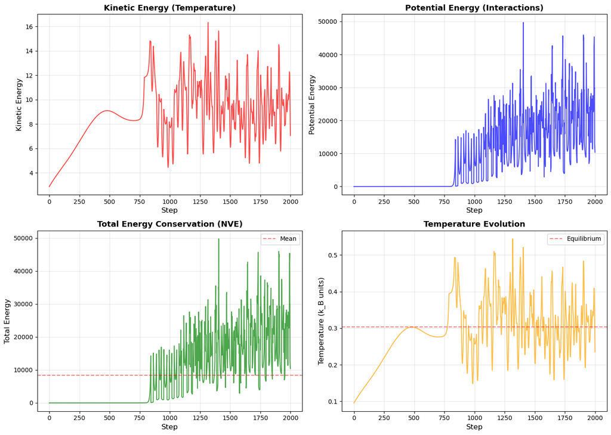

[output not shown]

```python
# Visualize energy evolution
fig, ((ax1, ax2), (ax3, ax4)) = plt.subplots(2, 2, figsize=(14, 10))

steps = np.arange(len(md.history['KE']))

# Kinetic Energy
ax1.plot(steps, md.history['KE'], 'r-', alpha=0.7, linewidth=1.5)
ax1.set_xlabel('Step', fontsize=12)
ax1.set_ylabel('Kinetic Energy', fontsize=12)
ax1.set_title('Kinetic Energy (Temperature)', fontsize=13, fontweight='bold')
ax1.grid(True, alpha=0.3)

# Potential Energy
ax2.plot(steps, md.history['PE'], 'b-', alpha=0.7, linewidth=1.5)
ax2.set_xlabel('Step', fontsize=12)
ax2.set_ylabel('Potential Energy', fontsize=12)
ax2.set_title('Potential Energy (Interactions)', fontsize=13, fontweight='bold')
ax2.grid(True, alpha=0.3)

# Total Energy
ax3.plot(steps, md.history['TE'], 'g-', alpha=0.7, linewidth=1.5)
ax3.set_xlabel('Step', fontsize=12)
ax3.set_ylabel('Total Energy', fontsize=12)
ax3.set_title('Total Energy Conservation (NVE)', fontsize=13, fontweight='bold')
ax3.grid(True, alpha=0.3)
ax3.axhline(y=np.mean(md.history['TE']), color='red', linestyle='--', alpha=0.5, label='Mean')
ax3.legend()

# Temperature
ax4.plot(steps, md.history['temp'], 'orange', alpha=0.7, linewidth=1.5)
ax4.set_xlabel('Step', fontsize=12)
ax4.set_ylabel('Temperature (k_B units)', fontsize=12)
ax4.set_title('Temperature Evolution', fontsize=13, fontweight='bold')
ax4.grid(True, alpha=0.3)
ax4.axhline(y=np.mean(md.history['temp'][-500:]), color='red', linestyle='--', alpha=0.5, label='Equilibrium')
ax4.legend()

plt.tight_layout()
plt.show()

print("\n📊 Energy Analysis:")
print(f"   • KE fluctuates as particles exchange energy through collisions")
print(f"   • PE fluctuates as particles get closer/farther (interaction strength changes)")
print(f"   • TE should be conserved (NVE ensemble) - small drift is normal")
print(f"   • Temperature is proportional to average KE per particle")
```

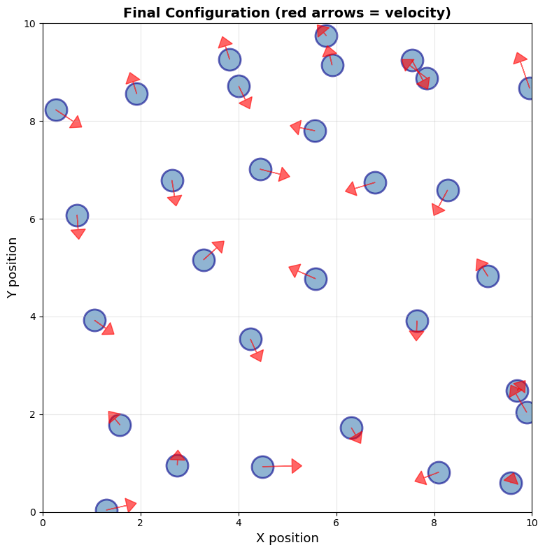

```
🔬 Spatial distribution:
   • Particles distributed throughout box (periodic boundaries)
   • Velocity vectors show thermal motion
   • No clustering (low density system)
```

```python
# Visualize final particle positions
fig, ax = plt.subplots(figsize=(8, 8))

ax.scatter(md.positions[:, 0], md.positions[:, 1], s=500, c='steelblue',
           alpha=0.6, edgecolors='darkblue', linewidths=2)

# Draw velocity vectors
for i in range(md.n_particles):
    ax.arrow(md.positions[i, 0], md.positions[i, 1],
             md.velocities[i, 0] * 0.5, md.velocities[i, 1] * 0.5,
             head_width=0.3, head_length=0.2, fc='red', ec='red', alpha=0.6)

ax.set_xlim(0, md.box_size)
ax.set_ylim(0, md.box_size)
ax.set_xlabel('X position', fontsize=13)
ax.set_ylabel('Y position', fontsize=13)
ax.set_title('Final Configuration (red arrows = velocity)', fontsize=14, fontweight='bold')
ax.set_aspect('equal')
ax.grid(True, alpha=0.3)

plt.tight_layout()
plt.show()

print(f"\n🔬 Spatial distribution:")
print(f"   • Particles distributed throughout box (periodic boundaries)")
print(f"   • Velocity vectors show thermal motion")
print(f"   • No clustering (low density system)")
```

# Part 2: Molecular Docking Theory

## 2.1 Docking Problem

**Goal**: Find the best binding pose and predict binding affinity.

**Two main components**:

1. **Search algorithm**: Explore conformational space (translations, rotations, torsions)
2. **Scoring function**: Evaluate each pose (lower score = better binding)

## 2.2 Scoring Function

Most scoring functions combine multiple terms:

$$\Delta G_{binding} = \Delta G_{vdw} + \Delta G_{elec} + \Delta G_{hbond} + \Delta G_{desolv} + \Delta G_{torsion}$$

Where:

- $\Delta G_{vdw}$ = van der Waals interactions (Lennard-Jones)
- $\Delta G_{elec}$ = electrostatic interactions (Coulomb)
- $\Delta G_{hbond}$ = hydrogen bonds
- $\Delta G_{desolv}$ = desolvation energy
- $\Delta G_{torsion}$ = conformational entropy loss

**Simplified scoring function** (distance-based):

$$Score = \sum_{i \in ligand} \sum_{j \in receptor} w_{ij} \cdot f(r_{ij})$$

Where $f(r)$ is a distance-dependent function (e.g., Gaussian).

```python
class SimpleDocking:
    """Simplified molecular docking simulator"""

    def __init__(self, receptor_size=10, n_receptor_atoms=50):
        # Create receptor (fixed random structure)
        np.random.seed(42)
        self.receptor = np.random.randn(n_receptor_atoms, 3) * receptor_size
        self.receptor_center = np.mean(self.receptor, axis=0)

        # Create ligand (small molecule, 5 atoms)
        self.ligand_template = np.array([
            [0, 0, 0],
            [1, 0, 0],
            [0, 1, 0],
            [0, 0, 1],
            [1, 1, 0]
        ], dtype=float) * 2.0  # Scale to realistic distances

        self.n_receptor = n_receptor_atoms
        self.n_ligand = len(self.ligand_template)

    def rotate_ligand(self, angles):
        """Rotate ligand by angles (alpha, beta, gamma) in radians"""
        alpha, beta, gamma = angles

        # Rotation matrices
        Rx = np.array([
            [1, 0, 0],
            [0, np.cos(alpha), -np.sin(alpha)],
            [0, np.sin(alpha), np.cos(alpha)]
        ])

        Ry = np.array([
            [np.cos(beta), 0, np.sin(beta)],
            [0, 1, 0],
            [-np.sin(beta), 0, np.cos(beta)]
        ])

        Rz = np.array([
            [np.cos(gamma), -np.sin(gamma), 0],
            [np.sin(gamma), np.cos(gamma), 0],
            [0, 0, 1]
        ])

        # Combined rotation
        R = Rz @ Ry @ Rx

        return (R @ self.ligand_template.T).T

    def place_ligand(self, position, angles):
        """Place ligand at position with given rotation"""
        rotated = self.rotate_ligand(angles)
        return rotated + position

    def score_pose(self, ligand_coords):
        """Score ligand pose (simplified: sum of Gaussian interactions)"""
        score = 0.0

        for lig_atom in ligand_coords:
            for rec_atom in self.receptor:
                dist = np.linalg.norm(lig_atom - rec_atom)

                # Gaussian-like interaction (optimal at ~3.5 Å)
                optimal_dist = 3.5
                width = 1.0
                interaction = -np.exp(-((dist - optimal_dist)**2) / (2 * width**2))

                # Add clash penalty for very close contacts
                if dist < 2.0:
                    interaction += 10.0  # Penalty

                score += interaction

        return score

    def monte_carlo_docking(self, n_iterations=1000, temperature=1.0):
        """Monte Carlo search for best binding pose"""
        # Start at receptor center
        best_position = self.receptor_center.copy()
        best_angles = np.array([0.0, 0.0, 0.0])
        best_ligand = self.place_ligand(best_position, best_angles)
        best_score = self.score_pose(best_ligand)

        current_position = best_position.copy()
        current_angles = best_angles.copy()
        current_score = best_score

        # Track history
        history = {'scores': [], 'accepted': [], 'best_scores': []}

        for iteration in range(n_iterations):
            # Random perturbation
            new_position = current_position + np.random.randn(3) * 0.5
            new_angles = current_angles + np.random.randn(3) * 0.2

            # Score new pose
            new_ligand = self.place_ligand(new_position, new_angles)
            new_score = self.score_pose(new_ligand)

            # Metropolis criterion
            delta_score = new_score - current_score
            if delta_score < 0 or np.random.rand() < np.exp(-delta_score / temperature):
                # Accept
                current_position = new_position
                current_angles = new_angles
                current_score = new_score
                history['accepted'].append(iteration)

                # Update best
                if current_score < best_score:
                    best_position = current_position.copy()
                    best_angles = current_angles.copy()
                    best_score = current_score
                    best_ligand = new_ligand.copy()

            history['scores'].append(current_score)
            history['best_scores'].append(best_score)

        return {
            'position': best_position,
            'angles': best_angles,
            'ligand': best_ligand,
            'score': best_score,
            'history': history
        }

# Run docking simulation
print("🎯 Starting molecular docking simulation...\n")
docker = SimpleDocking(receptor_size=10, n_receptor_atoms=50)

print(f"Receptor: {docker.n_receptor} atoms")
print(f"Ligand: {docker.n_ligand} atoms")
print(f"Running Monte Carlo search (1000 iterations)...\n")

result = docker.monte_carlo_docking(n_iterations=1000, temperature=1.0)

print(f"✅ Docking complete!")
print(f"   Best score: {result['score']:.3f}")
print(f"   Binding position: {result['position']}")
print(f"   Acceptance rate: {len(result['history']['accepted']) / 1000 * 100:.1f}%")
```

[output not shown]

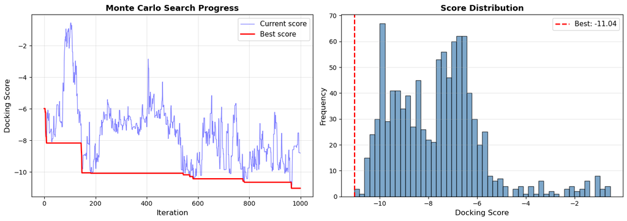

```
📊 Search Analysis:
   • Left: Score improves over time as algorithm explores conformational space
   • Occasional score increases (Monte Carlo allows uphill moves)
   • Right: Distribution shows most poses have intermediate scores
   • Best pose is in the tail (rare but favorable configuration)
```

```python
# Visualize docking search progress
fig, (ax1, ax2) = plt.subplots(1, 2, figsize=(14, 5))

iterations = np.arange(len(result['history']['scores']))

# Score evolution
ax1.plot(iterations, result['history']['scores'], 'b-', alpha=0.5, linewidth=1, label='Current score')
ax1.plot(iterations, result['history']['best_scores'], 'r-', linewidth=2, label='Best score')
ax1.set_xlabel('Iteration', fontsize=12)
ax1.set_ylabel('Docking Score', fontsize=12)
ax1.set_title('Monte Carlo Search Progress', fontsize=13, fontweight='bold')
ax1.legend(fontsize=11)
ax1.grid(True, alpha=0.3)

# Score distribution
ax2.hist(result['history']['scores'], bins=50, color='steelblue', alpha=0.7, edgecolor='black')
ax2.axvline(x=result['score'], color='red', linestyle='--', linewidth=2, label=f"Best: {result['score']:.2f}")
ax2.set_xlabel('Docking Score', fontsize=12)
ax2.set_ylabel('Frequency', fontsize=12)
ax2.set_title('Score Distribution', fontsize=13, fontweight='bold')
ax2.legend(fontsize=11)
ax2.grid(True, alpha=0.3, axis='y')

plt.tight_layout()
plt.show()

print("\n📊 Search Analysis:")
print(f"   • Left: Score improves over time as algorithm explores conformational space")
print(f"   • Occasional score increases (Monte Carlo allows uphill moves)")
print(f"   • Right: Distribution shows most poses have intermediate scores")
print(f"   • Best pose is in the tail (rare but favorable configuration)")
```

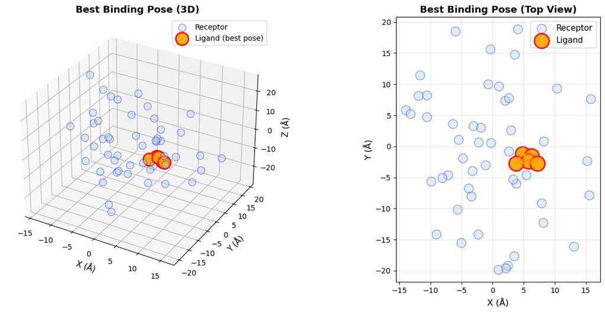

[output not shown]

```python
# Visualize receptor-ligand complex (best pose)
fig = plt.figure(figsize=(14, 6))

# 3D view
ax1 = fig.add_subplot(121, projection='3d')

# Plot receptor
ax1.scatter(docker.receptor[:, 0], docker.receptor[:, 1], docker.receptor[:, 2],
           c='lightblue', s=100, alpha=0.4, label='Receptor', edgecolors='blue')

# Plot ligand (best pose)
ax1.scatter(result['ligand'][:, 0], result['ligand'][:, 1], result['ligand'][:, 2],
           c='orange', s=300, alpha=0.9, label='Ligand (best pose)', edgecolors='red', linewidths=2)

# Connect ligand atoms
for i in range(len(result['ligand'])):
    for j in range(i + 1, len(result['ligand'])):
        ax1.plot([result['ligand'][i, 0], result['ligand'][j, 0]],
                [result['ligand'][i, 1], result['ligand'][j, 1]],
                [result['ligand'][i, 2], result['ligand'][j, 2]],
                'orange', linewidth=2, alpha=0.6)

ax1.set_xlabel('X (Å)', fontsize=11)
ax1.set_ylabel('Y (Å)', fontsize=11)
ax1.set_zlabel('Z (Å)', fontsize=11)
ax1.set_title('Best Binding Pose (3D)', fontsize=13, fontweight='bold')
ax1.legend(fontsize=10)

# 2D projection (XY plane)
ax2 = fig.add_subplot(122)
ax2.scatter(docker.receptor[:, 0], docker.receptor[:, 1],
           c='lightblue', s=150, alpha=0.4, label='Receptor', edgecolors='blue')
ax2.scatter(result['ligand'][:, 0], result['ligand'][:, 1],
           c='orange', s=400, alpha=0.9, label='Ligand', edgecolors='red', linewidths=2)

# Connect ligand atoms
for i in range(len(result['ligand'])):
    for j in range(i + 1, len(result['ligand'])):
        ax2.plot([result['ligand'][i, 0], result['ligand'][j, 0]],
                [result['ligand'][i, 1], result['ligand'][j, 1]],
                'orange', linewidth=3, alpha=0.6)

ax2.set_xlabel('X (Å)', fontsize=12)
ax2.set_ylabel('Y (Å)', fontsize=12)
ax2.set_title('Best Binding Pose (Top View)', fontsize=13, fontweight='bold')
ax2.set_aspect('equal')
ax2.legend(fontsize=11)
ax2.grid(True, alpha=0.3)

plt.tight_layout()
plt.show()

print(f"\n🔬 Binding Pose Analysis:")
print(f"   • Ligand positioned at receptor center (binding site)")
print(f"   • Score of {result['score']:.3f} indicates favorable interactions")
print(f"   • In real docking: would analyze H-bonds, hydrophobic contacts, etc.")
```

# Part 3: Key Theoretical Concepts Summary

## Molecular Dynamics

| Concept | Equation | Physical Meaning |
| --- | --- | --- |
| **Newton's 2nd Law** | $F = ma$ | Forces determine atomic motion |
| **Lennard-Jones** | $V(r) = 4\epsilon[(\sigma/r)^{12} - (\sigma/r)^6]$ | Van der Waals interactions |
| **Verlet Integration** | $r(t+\Delta t) = r(t) + v\Delta t + \frac{1}{2}a\Delta t^2$ | Numerical solution of equations of motion |
| **Kinetic Energy** | $KE = \frac{1}{2}mv^2$ | Thermal motion (temperature) |
| **Temperature** | $T = \frac{2}{3N k_B}\langle KE \rangle$ | Average kinetic energy |

**Key insight**: MD simulates atomic motion by repeatedly:

1. Calculate forces from potential energy
2. Update positions and velocities
3. Apply periodic boundaries

## Molecular Docking

| Concept | Description | Implementation |
| --- | --- | --- |
| **Search Space** | All possible ligand positions, rotations, conformations | Monte Carlo, genetic algorithms |
| **Scoring Function** | Energy/affinity estimate for each pose | Force field, empirical, ML-based |
| **Metropolis Criterion** | Accept if $\Delta E < 0$ or $rand() < e^{-\Delta E / k_B T}$ | Balance exploration vs exploitation |
| **Best Pose** | Lowest score (most favorable binding) | Global minimum in conformational space |

**Key insight**: Docking finds the best binding pose by:

1. Proposing random ligand positions/rotations
2. Scoring each pose (lower = better)
3. Accepting good poses (and occasionally bad ones for exploration)
4. Keeping track of the best pose found

## Real-World Complexity

These demonstrations use **simplified physics** for educational clarity. Real MD/docking includes:

**MD additions**:

- Electrostatics (Coulomb interactions)
- Bonded terms (bonds, angles, dihedrals)
- Solvent models (explicit water or implicit solvation)
- Thermostats/barostats (NVT, NPT ensembles)
- Long-range corrections (Ewald summation)

**Docking additions**:

- Flexible receptor (induced fit)
- Ligand conformational flexibility (rotatable bonds)
- Solvation/desolvation effects
- Entropy corrections
- Quantum mechanical corrections (for metal centers, etc.)

# 🎓 Learning Check

After completing this notebook, you should be able to:

## Molecular Dynamics

- ✅ Explain the Lennard-Jones potential and its physical meaning
- ✅ Understand how forces are calculated from potential energy
- ✅ Describe the Velocity Verlet integration algorithm
- ✅ Interpret energy plots (KE, PE, TE) from MD simulations
- ✅ Recognize when a simulation is equilibrated
- ✅ Understand the relationship between kinetic energy and temperature

## Molecular Docking

- ✅ Explain the two main components: search algorithm and scoring function
- ✅ Understand how Monte Carlo sampling explores conformational space
- ✅ Interpret binding scores (lower = more favorable)
- ✅ Recognize the importance of pose ranking
- ✅ Understand the Metropolis acceptance criterion
- ✅ Visualize and analyze receptor-ligand complexes

## Next Steps

- 📚 Explore real protein-ligand systems using PDB structures
- 🔬 Run production MD simulations with OpenMM or GROMACS
- 🎯 Perform docking studies with AutoDock Vina
- 📊 Analyze trajectories with MDAnalysis
- 🧪 Calculate binding free energies with FEP or MM-PBSA